# Cuadro depresivo vs: alcoholismo, salario medio y horas de luz

Henar Ronda, Yasmina Álamo y Raúl Ortega

11 diciembre 2023

# **Introducción**

## **Depresión**

### *Datos sobre la depresión*

Para el análisis trabajaremos sobre el índice que indica el nivel de depresión A continuación se mostrarán los datos del cuadro depresivo mayor por Comunidad Autónoma. Importamos la biblioteca correspondiente para poder leer el archivo csv:

```r
library(readxl)
library(DT)
library(dplyr)
```

Importamos los datos a tratar y los mostramos como una tabla. Los datos se refieren a una población de 15 años y más, y la medida l encontramos en porcentaje, es decir, la proporción de personas que padecen un cuadro depresivo mayor por cada 100 personas. Antes de ponernos a analizar, describiremos brevemente las características de esta prevalencia. Algunas de las más importantes son: - Fatiga y falta de energía - Sentimientos de desesperanza, inutilidad u odio a si mismo - Pérdida de interés en actividades que se disfrutaban - Dificultad de concentración - Dificultad para conciliar el sueño - Cambio súbito en el apetito

```r
depresion <- read.csv("INPUT/DATA/depresion_cambiado.csv",
    sep = ";", fileEncoding = "Latin1", header = TRUE, stringsAsFactors = FALSE)%>%
  select(Comunidades.y.Ciudades.Autónomas, Total)

depresion$Comunidades.y.Ciudades.Autónomas[depresion$Comunidades.y.Ciudades.Autónomas == ""] <- "Media Nacional"
datatable(depresion)
```

|  | Comunidades.y.Ciudades.Autónomas | Total |
| --- | --- | --- |
| 1 | Media Nacional | 3,52 |
| 2 | Andalucía | 5,26 |
| 3 | Aragón | 2,87 |
| 4 | Asturias (Principado de) | 7,71 |
| 5 | Balears (Illes) | 4,02 |
| 6 | Canarias | 5,73 |
| 7 | Cantabria | 4,18 |
| 8 | Castilla y León | 2,22 |
| 9 | Castilla-La Mancha | 2,19 |
| 10 | Cataluña | 3,34 |

[output cut: 10 more lines]

## **Alcoholismo**

### *Datos sobre el alcoholismo:*

En primer lugar tenemos un conjunto de datos que estudian la cantidad de alcohol que se consume por Comunidad Autónoma. La medida total se encuentra en gramos de alcohol puro diario por personas que beben más de una vez al mes donde, por ejemplo, una cerveza con alcohol equivale a 10 g.

No es necesario importar la biblioteca que nos permitirá leer el archivo csv ya que ha sido importada anteriormente.

Importamos los datos mediante el siguiente código:

```r
library(dplyr)
alcohol <- read.csv("INPUT/DATA/ALCOHOL.csv",
    sep = ";", fileEncoding = "Latin1", header = TRUE, stringsAsFactors = FALSE)%>%
  select(Comunidades.y.Ciudades.Autónomas, Total)

alcohol$Comunidades.y.Ciudades.Autónomas[alcohol$Comunidades.y.Ciudades.Autónomas == ""] <- "Media Nacional"
datatable(alcohol)
```

|  | Comunidades.y.Ciudades.Autónomas | Total |
| --- | --- | --- |
| 1 | Media Nacional | 11,79 |
| 2 | Andalucía | 11,32 |
| 3 | Aragón | 13,55 |
| 4 | Asturias, Principado de | 14,63 |
| 5 | Balears, Illes | 11,81 |
| 6 | Canarias | 12,06 |
| 7 | Cantabria | 8,67 |
| 8 | Castilla y León | 15,91 |
| 9 | Castilla-La Mancha | 15,06 |
| 10 | Cataluña | 9,91 |

[output cut: 10 more lines]

### *Comparación con la depresión*

Para poder comparar los datos y sacar conclusiones, hemos de cruzar las tablas y obtener una gráfica que nos permita observar la relación existente entre ambos factores. Para ello realizaremos el siguiente código donde seleccionamos como atributo común las distintas Comunidades Autónomas y sus respectivos datos tanto de consumo de alcohol como de prevalencia de depresión

```r
comparacion<-inner_join(depresion, alcohol, by= "Comunidades.y.Ciudades.Autónomas")
tabla_final <- comparacion %>%
  select("Comunidades Autónomas"="Comunidades.y.Ciudades.Autónomas", "Prevalencia Depresión"=Total.x, "Consumo Alcohol"=Total.y)
```

```r
dep_alc <- data.frame("Comunidades Autónomas" = depresion$Comunidades.y.Ciudades.Autónomas, "Prevalencia Depresión" = depresion$Total, "Alcohol" = alcohol$Total)
datatable(dep_alc)
```

|  | Comunidades.Autónomas | Prevalencia.Depresión | Alcohol |
| --- | --- | --- | --- |
| 1 | Media Nacional | 3,52 | 11,79 |
| 2 | Andalucía | 5,26 | 11,32 |
| 3 | Aragón | 2,87 | 13,55 |
| 4 | Asturias (Principado de) | 7,71 | 14,63 |
| 5 | Balears (Illes) | 4,02 | 11,81 |
| 6 | Canarias | 5,73 | 12,06 |
| 7 | Cantabria | 4,18 | 8,67 |
| 8 | Castilla y León | 2,22 | 15,91 |
| 9 | Castilla-La Mancha | 2,19 | 15,06 |
| 10 | Cataluña | 3,34 | 9,91 |

[output cut: 10 more lines]

Tras hallar la tabla realizada a través de un join para visualizar de forma más clara los datos unidos, procedemos a representar visualmente dichos datos de forma que nos permita ver realmente la relación entre ambas variables.

Para ello lo primero que hacemos es importar la librería que necesitamos para los gráficos.

```r
library(tidyverse)
```

```r
library(ggplot2)
```

A continuación, el código junto a los resultados:

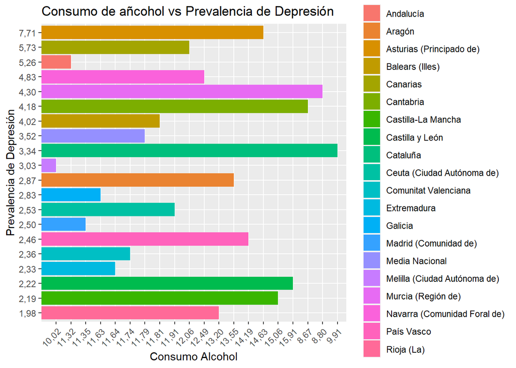

```r
ggplot(dep_alc, aes(y = `Alcohol`, x = `Prevalencia.Depresión`, fill = `Comunidades.Autónomas`)) +
  geom_col(position = "dodge") +
  labs(title = "Consumo de añcohol vs Prevalencia de Depresión", y = "Consumo Alcohol", x = "Prevalencia de Depresión") +
  theme(axis.text.x = element_text(angle = 45, hjust = 1)) +
  coord_flip()
```

Graficamos los mismos datos mediante un gráfico de puntos o dispersión para ver la correlación

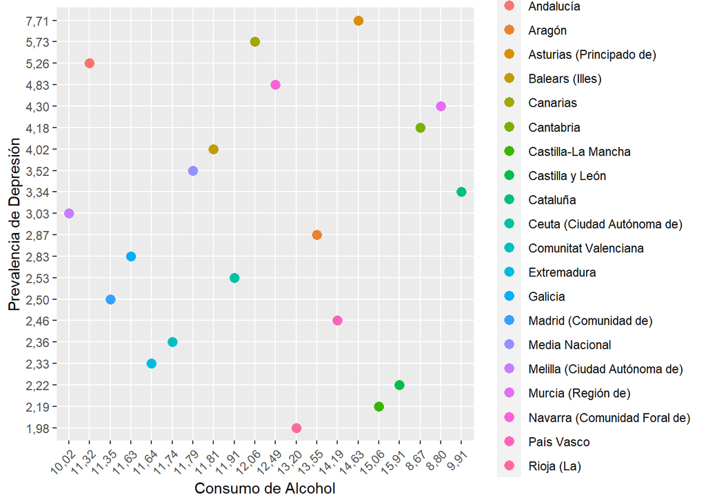

```r
# Graficar los mismos datos como un gráfico de puntos

ggplot(dep_alc, aes(y = `Alcohol`, x = `Prevalencia.Depresión`, color = `Comunidades.Autónomas`)) +
  geom_point(size = 3) +  # Utilizamos geom_point para gráfico de puntos
  labs(y = "Consumo de Alcohol", x = "Prevalencia de Depresión") +

  theme(axis.text.x = element_text(angle = 45, hjust = 1)) +
  coord_flip()
```

## **Salario**

### *Datos sobre el salario medio*

Este factor que analizaremos tiene en cuenta el salario medio anual por individuo dependiendo de la Comunidad Autónoma en la que se encuentre.

Para poder trabajar datos en formato **JSON** tenemos que importar primero esta biblioteca:

```r
library(jsonlite)
library(knitr)
```

Ruta al archivo JSON

```r
ruta_archivo<-"INPUT/DATA/salarios.json"
```

Extraemos los datos de los salarios mediante un bucle donde solamente nos quedamos con la parte del atributo donde vienen los nombres de las Comunidades Autónomas, ya que en los datos en crudo los nombres no vienen como tal:

```r
salarios<-fromJSON(ruta_archivo)
tabla_salarios <- data.frame(Nombres = character(), Total = numeric())
a <- mapply(list, salarios$Nombre, salarios$Data, SIMPLIFY = FALSE)
for (i in a){
  if(grepl("decil", i[[1]]) & !grepl("Jornada", i[[1]])) {
    tabla_salarios <- rbind(tabla_salarios, data.frame(Nombres = i[[1]], Salario = i[[2]]$Valor))
  }
}

tabla_salarios <- tabla_salarios %>%
  separate(Nombres, into = c("Tot", "Comunidades.y.Ciudades.Autónomas","base","decil", "Salario medio"), sep = "\\.")%>%
  select(Comunidades.y.Ciudades.Autónomas, Salario)
tabla_salarios$Comunidades.y.Ciudades.Autónomas[1] <- "Media Nacional"
datatable(tabla_salarios)
```

|  | Comunidades.y.Ciudades.Autónomas | Salario |
| --- | --- | --- |
| 1 | Media Nacional | 2086.78 |
| 2 | Andalucía | 1860.56 |
| 3 | Aragón | 1994.02 |
| 4 | Asturias, Principado de | 2079.31 |
| 5 | Balears, Illes | 2073.06 |
| 6 | Canarias | 1984.8 |
| 7 | Cantabria | 2059.75 |
| 8 | Castilla y León | 1983.71 |
| 9 | Castilla - La Mancha | 1925.46 |
| 10 | Cataluña | 2214.91 |

[output cut: 10 more lines]

### *Comparación con la depresión*

De nuevo, antes de visualizar el gráfico procedemos a unir los datos que queremos comparar en una sola tabla con el nombre de las Comunidades como atributo común a la tabla de Depresión y a la correspondiente al Salario.

```r
dep_sal <- data.frame("Comunidades Autónomas" = depresion$Comunidades.y.Ciudades.Autónomas, "Prevalencia Depresión" = depresion$Total, "Salario" = tabla_salarios$Salario)

datatable(dep_sal)
```

|  | Comunidades.Autónomas | Prevalencia.Depresión | Salario |
| --- | --- | --- | --- |
| 1 | Media Nacional | 3,52 | 2086.78 |
| 2 | Andalucía | 5,26 | 1860.56 |
| 3 | Aragón | 2,87 | 1994.02 |
| 4 | Asturias (Principado de) | 7,71 | 2079.31 |
| 5 | Balears (Illes) | 4,02 | 2073.06 |
| 6 | Canarias | 5,73 | 1984.8 |
| 7 | Cantabria | 4,18 | 2059.75 |
| 8 | Castilla y León | 2,22 | 1983.71 |
| 9 | Castilla-La Mancha | 2,19 | 1925.46 |
| 10 | Cataluña | 3,34 | 2214.91 |

[output cut: 10 more lines]

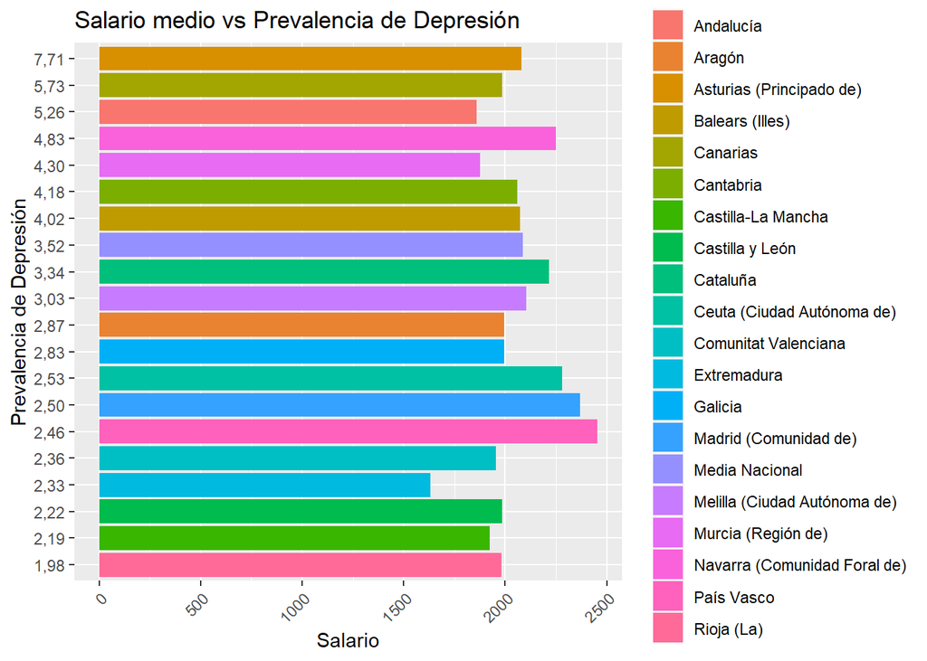

```r
ggplot(dep_sal, aes(y = `Salario`, x = `Prevalencia.Depresión`, fill = `Comunidades.Autónomas`)) +
  geom_col(position = "dodge") +
  labs(title = "Salario medio vs Prevalencia de Depresión", y = "Salario", x = "Prevalencia de Depresión") +
  theme(axis.text.x = element_text(angle = 45, hjust = 1)) +
  coord_flip()
```

Ahora realizamos un gráfico para ver la correlación entre estos dos factores:

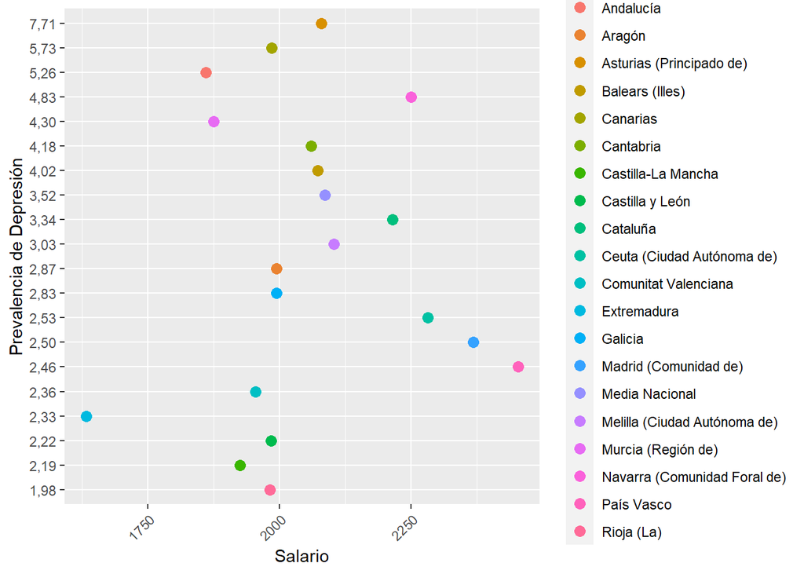

```r
ggplot(dep_sal, aes(y = `Salario`, x = `Prevalencia.Depresión`, color = `Comunidades.Autónomas`)) +
  geom_point(size = 3) +
  labs(y = "Salario", x = "Prevalencia de Depresión") +

  theme(axis.text.x = element_text(angle = 45, hjust = 1)) +
  coord_flip()
```

## **Horas de luz**

Según algunos estudios, la depresión estacional puede aparecer debido a la respuesta del cerebro a la disminución de las horas de luz solar. La luz solar afecta a dos sustancias químicas cerebrales: la melatonina y la serotonina. Estas sustancias ayudan a regular los ciclos de sueño-vigilia, la energía y el estado de ánimo. Si la luz solar en nuestra vida se ve reducida, esto provoca una caída en los niveles de serotonina y por ende, más propensión a padecer ciertas enfermedades mentales.

### *Datos sobre horas de luz*

En este caso estudiaremos el número de horas de luz que disfruta cada provincia en España al año. Los datos los tenemos agrupados por provincias, por lo que hemos de cambiarlo a Comunidades Autónomas. Esta información procede de una página web. Para poder trabajar con los datos usaremos las siguiente librerias.

```r
 library(rvest)
 library(XML)
 library(xml2)
 library(tidyverse)
```

Leemos la página:

```r
 document <- read_html("https://facturadelaluz.com/solar/que-provincias-tienen-mas-horas-de-sol/")
```

Seleccionamos los datos con los que queremos trabajar, en este caso las tablas:

```r
html_products <- document %>% html_elements(".table-default")
html_products
```

```
## {xml_nodeset (17)}
##  [1] <table class="table-default">\n<thead><tr><th class="text-bold">HORAS DE ...
##  [2] <table class="table-default">\n<thead><tr><th class="text-bold">HORAS DE ...
##  [3] <table class="table-default">\n<thead><tr><th class="text-bold">HORAS DE ...
##  [4] <table class="table-default">\n<thead><tr><th class="text-bold">HORAS DE ...
##  [5] <table class="table-default">\n<thead><tr><th class="text-bold">HORAS DE ...
##  [6] <table class="table-default">\n<thead><tr><th class="text-bold">HORAS DE ...
##  [7] <table class="table-default">\n<thead><tr><th class="text-bold">HORAS DE ...
##  [8] <table class="table-default">\n<thead><tr><th class="text-bold">HORAS DE ...
##  [9] <table class="table-default">\n<thead><tr><th class="text-bold">HORAS DE ...
## [10] <table class="table-default">\n<thead><tr><th class="text-bold">HORAS DE ...
## [11] <table class="table-default">\n<thead><tr><th class="text-bold">HORAS DE ...
## [12] <table class="table-default">\n<thead><tr><th class="text-bold">HORAS DE ...
## [13] <table class="table-default">\n<thead><tr><th class="text-bold">HORAS DE ...
## [14] <table class="table-default">\n<thead><tr><th class="text-bold">HORAS DE ...
## [15] <table class="table-default">\n<thead><tr><th class="text-bold">HORAS DE ...
## [16] <table class="table-default">\n<thead><tr><th class="text-bold">HORAS DE ...
## [17] <table class="table-default">\n<thead><tr><th class="text-bold">HORAS DE ...
```

Creamos un vector con los nombres de las comunidades autonomas:

```r
com_autom <- c("Andalucía",
"Aragón",
"Asturias (Principado de)",
"Cantabria",
"Cataluña",
"Castilla y León",
"Castilla-La Mancha",
"Madrid (Comunidad de)",
"Comunitat Valenciana",
"Extremadura",
"Galicia",
"Balears (Illes)",
"Canarias",
"Rioja (La)",
"Murcia (Región de)",
"Navarra (Comunidad Foral de)",
"País Vasco")
```

Elaboramos un bucle para poder trabajar con la información de cada nodo XML. Finalmente, almacenamos los valores de horas de luz de cada provincia en una lista, separándolas por comunidades autónomas.

```r
# Creamos una lista vacía para almacenar los vectores
lista_datos_luz <- list()

for(i in seq_along(html_products)){ # Iteramos sobre los nodos de nuestro archivo xml

    node_content <- xml_text(html_products[i]) # Extraemos la información de cada tabla

    sinpunt <- gsub("\\.", "", node_content) # Eliminamos los puntos de los digitos
    es <- str_extract_all(sinpunt, "\\d+") # Extraemos unicamente los números
    num <- as.numeric(unlist(es)) # Pasamos de una string a numeric
    datos_luz <- num[num > 1000]

    # Añado datos_luz a la lista
    lista_datos_luz[[i]] <- datos_luz
}
```

Calculamos la media de las horas de luz de cada comunidad autónoma. Para ello usaremos la función mean().

```r
# Calculo la media de las horas de luz de cada comunidad autonoma
horasLuzMedia <- list()
for(m in 1:17){
  media <- mean(lista_datos_luz[[m]])
  horasLuzMedia[[m]] <- media
}
```

Para poder trabajar con los datos obtenidos de la página web creamos un data frame. En una columna aparecerán los nombres de las comunidades autónomas y en la otra su media de las horas de luz correspondiente:

```r
# Creo un dataframe vacío
horas_luz <- data.frame(ComunidadesAutonomas = character(), HorasDeLuzMedia = numeric())

for(x in seq_along(horasLuzMedia)){
  # Añado una nueva fila al dataframe
  horas_luz <- rbind(horas_luz, data.frame(Comunidades.y.Ciudades.Autónomas = com_autom[x], HorasDeLuzMedia = horasLuzMedia[[x]]))
}
horas_luz
```

```
##    Comunidades.y.Ciudades.Autónomas HorasDeLuzMedia
## 1                         Andalucía        3344.375
## 2                            Aragón        2910.000
## 3          Asturias (Principado de)        1962.000
## 4                         Cantabria        1639.000
## 5                          Cataluña        2776.000
## 6                   Castilla y León        3014.200
## 7                Castilla-La Mancha        2950.500
## 8             Madrid (Comunidad de)        2691.000
## 9              Comunitat Valenciana        3175.333
## 10                      Extremadura        3294.500
## 11                          Galicia        2776.000
## 12                  Balears (Illes)        3039.500
## 13                         Canarias        2940.667
## 14                       Rioja (La)        2708.000
## 15               Murcia (Región de)        3348.000
## 16     Navarra (Comunidad Foral de)        2285.000
## 17                       País Vasco        1915.667
```

### *Comparación con la depresión*

A continuación se muestra el código empleado para obtener una tabla. Donde se han cruzado los datos de las horas de luz y la información sobre el nivel de depresión en cada comunidad autónoma.

```r
cruze <- inner_join(depresion, horas_luz, by= "Comunidades.y.Ciudades.Autónomas")
cruze
```

```
##    Comunidades.y.Ciudades.Autónomas Total HorasDeLuzMedia
## 1                         Andalucía  5,26        3344.375
## 2                            Aragón  2,87        2910.000
## 3          Asturias (Principado de)  7,71        1962.000
## 4                   Balears (Illes)  4,02        3039.500
## 5                          Canarias  5,73        2940.667
## 6                         Cantabria  4,18        1639.000
## 7                   Castilla y León  2,22        3014.200
## 8                Castilla-La Mancha  2,19        2950.500
## 9                          Cataluña  3,34        2776.000
## 10             Comunitat Valenciana  2,36        3175.333
## 11                      Extremadura  2,33        3294.500
## 12                          Galicia  2,83        2776.000
## 13            Madrid (Comunidad de)  2,50        2691.000
## 14               Murcia (Región de)  4,30        3348.000
## 15     Navarra (Comunidad Foral de)  4,83        2285.000
## 16                       País Vasco  2,46        1915.667
## 17                       Rioja (La)  1,98        2708.000
```

A partir de la tabla cruzada, creamos un gráfico de dispersión para observar su relación:

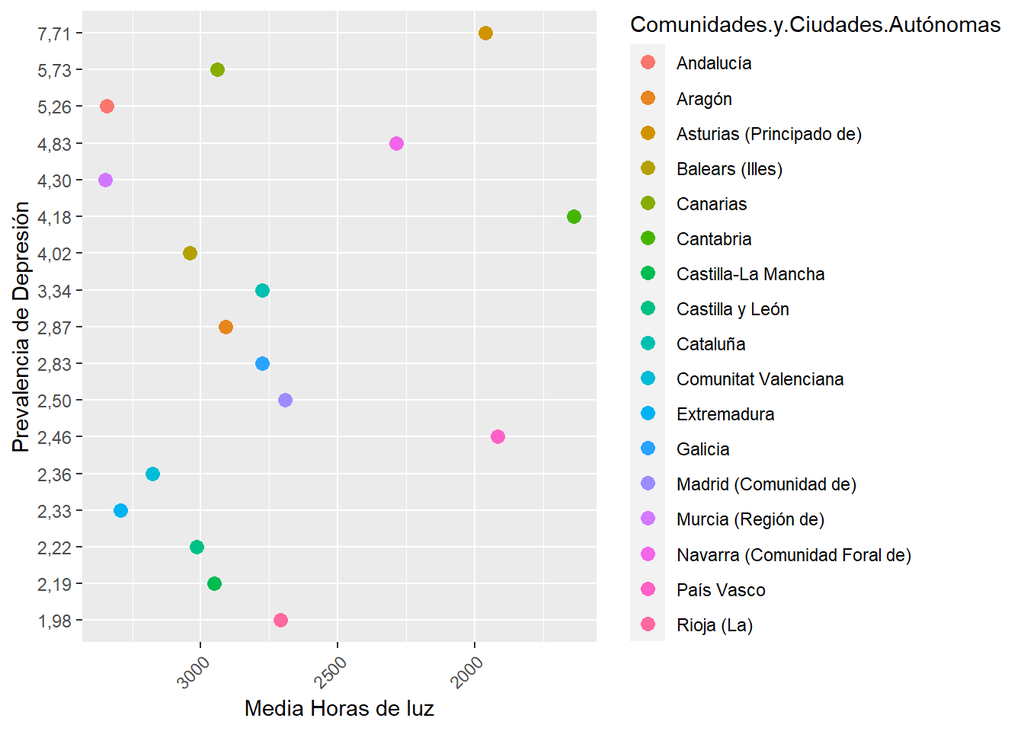

```r
ggplot(cruze, aes(x = `Total`, y = `HorasDeLuzMedia`, color = `Comunidades.y.Ciudades.Autónomas`)) +
  geom_point(size = 3 ) +
  labs(x = "Prevalencia de Depresión", y = "Media Horas de luz") +
  scale_y_continuous(trans="reverse") +
  theme(axis.text.x = element_text(angle = 45, hjust = 1)) +
  coord_flip()
```

Para tener otra perspectiva vamos a crear un gráfico de barras:

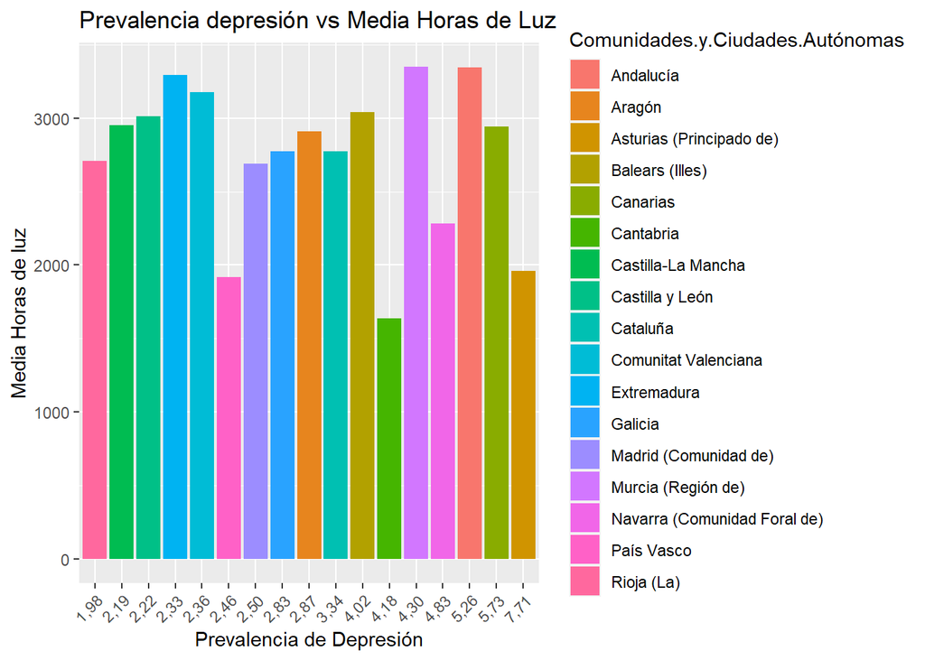

```r
ggplot(data = cruze) +
  geom_bar(stat = "identity",
           mapping = aes(x = Total, y = HorasDeLuzMedia,fill = `Comunidades.y.Ciudades.Autónomas`)) +
  labs(title = "Prevalencia depresión vs Media Horas de Luz", x = "Prevalencia de Depresión", y = "Media Horas de luz") +
  theme(axis.text.x = element_text(angle = 45, hjust = 1))
```

### *Análisis breve*

Hay un caso que llama la atención y sería el de Asturias, donde sí que observamos que tiene el mayor índice de depresión siendo una de las Comunidades Autónomas con menor número de horas al año, lo cual nos puede servir para sacar conclusiones.Andalucía, por el contrario disfrutan de una mayor luz, y sin embargo la tasa de depresión es de las más altas, lo que puede deberse también a otros factores sociales, económicos, etc…Sin descartar la teoría de la relación entre la excasez de luz solar y el padecimiento de depresión.  
En Cantabria también vemos que en menor medida se cumple este supuesto.

# **Conclusión**

A lo largo de nuestro estudio hemos ido comparando las variables que pensábamos que tendrían una cierta relación con la tasa de depresión por comunidades autónomas, creyendo que hay ciertos factores distintos entre ellas que hacen que por eso la tasa también sea distinta.  
En las tres comparaciones no hemos podido sacar una conclusión sólida de que haya la relación que esperábamos, aunque se puede deber a muchos factores, entre ellos el enfoque del estudio de la depresión, pues lo hemos realizado en base al cuadro depresivo, y existen otros cuadros más leves pero que también podrían estar relacionados con estos factores y no han sido incluidos en este estudio.  
Aún así, pese a los resultados, son factores que por sí solos afectan indudablemente al estado de ánimo y que por diferentes circunstancias podrán dar lugar a un desarrollo de las enfermedades mentales que hoy en día son cada vez más comunes y que hemos de afrontar.